# MTH365: Introduction to Data Science

Statistical Foundations

September 26, 2023

```r
#Required Packages

library(tidyverse)
library(knitr)
library(RColorBrewer)
library(mosaic)
library(infer)
```

### Isn’t this data science?

- Statistics: Statistics is a mathematically based field which seeks to collect and interpret quantitative data.
- Data science: Data science is a multidisciplinary filed which uses scientific methods, processes and system to extract information from data in a large range of forms.

Data science techniques can provide us a clean data and its visualization but we still reply on statistics theory to interpret what the data is trying to tell us

### Introduction

In data science we want to extract meaning from the data

- Data wrangling
- Visualization

Visualizations are powerful because humans are good at seeing patterns! However, we are also very good at seeing patterns that do not exist!

- Statistical Methods collect data and quantifies patterns in the data

Moral of the story: Data science techniques can provide us clean data and visualizations but we still rely on statistical theory to interpret what the data is trying to tell us

### Samples and Population

In statistics we are interested in a **population** of cases/people/objects. However, often this population is too large to collect data on, so we take **samples** from the larger population.

Statistical methodology assumes that the cases are drawn from a much larger set of potential cases, so the given data are a sample of a larger population of potential cases. - Other samples that might have been drawn from the population.

**Next**: - Why sample? - Requirements of a “good” sample?

## Example: Setting travel policy by sampling from the population

Example: You’ve been asked to develop a travel policy for business travelers going from New York City to Chicago. Assume that the `nycflights13` data sets represents the complete population of flights.

What would we do?

Let’s first filter all the flights going to Chicago and with a non-NA value of arrival delay time.

```r
library(nycflights13)
Chicago <- flights %>%
  filter(dest %in% c('ORD', 'MDW'), !is.na(arr_delay))
nrow(Chicago)
```

```
## [1] 20591
```

## Let’s find a Sample!

```r
set.seed(365)
Sample100 <- Chicago %>% sample_n(size=100)
glimpse(Sample100)
```

```
## Rows: 100
## Columns: 19
## $ year           <int> 2013, 2013, 2013, 2013, 2013, 2013, 2013, 2013, 2013, 2…
## $ month          <int> 9, 12, 7, 10, 10, 6, 4, 4, 6, 9, 4, 11, 10, 9, 6, 1, 2,…
## $ day            <int> 15, 18, 2, 10, 7, 24, 28, 18, 2, 8, 25, 14, 29, 8, 20, …
## $ dep_time       <int> 603, 2034, 1800, 629, 2116, 1156, 1759, 906, 1157, 1325…
## $ sched_dep_time <int> 601, 2035, 1805, 630, 1901, 1200, 1800, 630, 1200, 1330…
## $ dep_delay      <dbl> 2, -1, -5, -1, 135, -4, -1, 156, -3, -5, -3, -4, -4, 19…
## $ arr_time       <int> 717, 2153, 1926, 737, 2226, 1300, 1910, 1244, 1303, 145…
## $ sched_arr_time <int> 730, 2210, 1950, 805, 2040, 1333, 1944, 804, 1310, 1510…
## $ arr_delay      <dbl> -13, -17, -24, -28, 106, -33, -34, 280, -7, -18, 33, -2…
## $ carrier        <chr> "UA", "WN", "AA", "AA", "UA", "UA", "UA", "B6", "WN", "…
## $ flight         <int> 1143, 168, 353, 303, 693, 255, 994, 905, 654, 331, 329,…
## $ tailnum        <chr> "N68453", "N930WN", "N3CPAA", "N489AA", "N429UA", "N824…
## $ origin         <chr> "EWR", "LGA", "LGA", "LGA", "LGA", "LGA", "EWR", "JFK",…
## $ dest           <chr> "ORD", "MDW", "ORD", "ORD", "ORD", "ORD", "ORD", "ORD",…
## $ air_time       <dbl> 116, 116, 117, 105, 111, 106, 104, 168, 110, 114, 116, …
## $ distance       <dbl> 719, 725, 733, 733, 733, 733, 719, 740, 711, 733, 733, …
## $ hour           <dbl> 6, 20, 18, 6, 19, 12, 18, 6, 12, 13, 12, 11, 12, 20, 21…
## $ minute         <dbl> 1, 35, 5, 30, 1, 0, 0, 30, 0, 30, 25, 25, 0, 30, 0, 50,…
## $ time_hour      <dttm> 2013-09-15 06:00:00, 2013-12-18 20:00:00, 2013-07-02 1…
```

### Finding Summary Statistics

How long of a delay should we expect based on the sample? We can look at the mean, minimum, maximum, and standard deviation to get some idea.

```r
Sample100 %>% summarize(mean=mean(arr_delay),
                        min=min(arr_delay),
                        max=max(arr_delay),
                        sd=sd(arr_delay))
```

```
## # A tibble: 1 × 4
##    mean   min   max    sd
##   <dbl> <dbl> <dbl> <dbl>
## 1  8.96   -39   280  46.5
```

We might also want to examine the quantiles.

```r
Sample100 %>% summarize(q05=quantile(arr_delay, 0.05),
                        q25=quantile(arr_delay, 0.25),
                        median=median(arr_delay),
                        q75=quantile(arr_delay, 0.75),
                        q95=quantile(arr_delay, 0.95))
```

```
## # A tibble: 1 × 5
##     q05   q25 median   q75   q95
##   <dbl> <dbl>  <dbl> <dbl> <dbl>
## 1   -33   -18   -6.5  17.2  102.
```

Sorting the values from min to max, Quantile X means there are x% of values less than it:

- ie. 75% of the values are less than 17.2

### What constitutes an “unacceptable” delay?

How about an one and half hour delay?

```r
Chicago %>% mutate(less90 = arr_delay<=90) %>%
  group_by(less90) %>%
  summarize(n=n())
```

```
## # A tibble: 2 × 2
##   less90     n
##   <lgl>  <int>
## 1 FALSE   1197
## 2 TRUE   19394
```

#### Take Another sample

```r
set.seed(10)
Sample100_2 <- Chicago %>% sample_n(size=100)

Sample100_2 %>% summarize(mean=mean(arr_delay),
            min=min(arr_delay),
            max=max(arr_delay),
            sd=sd(arr_delay))
```

```
## # A tibble: 1 × 4
##    mean   min   max    sd
##   <dbl> <dbl> <dbl> <dbl>
## 1  9.64   -42   175  46.4
```

The sample mean is now 9.64. Is this the same or different than the previous sample?

Different samples of data will have different sample statistics!

### Compare to Population to Check Sample

```r
Sample100_2 %>% summarize(mean=mean(arr_delay), #sample
            min=min(arr_delay),
            max=max(arr_delay),
            sd=sd(arr_delay))
```

```
## # A tibble: 1 × 4
##    mean   min   max    sd
##   <dbl> <dbl> <dbl> <dbl>
## 1  9.64   -42   175  46.4
```

```r
Chicago %>% summarize(mean=mean(arr_delay), #population
            min=min(arr_delay),
            max=max(arr_delay),
            sd=sd(arr_delay))
```

```
## # A tibble: 1 × 4
##    mean   min   max    sd
##   <dbl> <dbl> <dbl> <dbl>
## 1  7.14   -62  1109  47.9
```

However, in most real-world settings, we do not have access to the population data. We have only our sample.

### Sample statistics

Statistic: A quantity computed from values in a sample to represent some characteristics

Examples:

- Mean $(\bar{x})$
- Proportion $(\hat{p})$
- Median $(m)$
- Standard Deviation $(s)$
- Sample Size $(n)$

### Sampling Distributions

Sample statistics depend completely on the data. Different samples of data will have different sample statistics!

We need to figure out the reliability of a sample statistic from the sample itself. + For now, though, we are going to use the population to develop some ideas about how to define reliability.

If we draw many different samples from the population, each of size $n$, and calculated the sample statistic on each of those samples, how similar would the sample statistic be across all the samples? + Do so by creating a sampling distribution

**Sampling distribution**: a set of probabilities represents the chance to see certain values of the statistics + There are three components for a sampling distribution: center (mean), spread (standard error) and shape. + [Animation](https://onlinestatbook.com/stat_sim/sampling_dist/index.html)

### Creating a Sampling Distribution

We could run the previous code multiple times to obtain our different samples

Or, we could speed it up:

```r
n <- 100
num_trials <- 500
chi_25_means <- 1:num_trials %>%
  map(~Chicago %>% slice_sample(n = n) %>%
        summarize(mean_arr_delay = mean(arr_delay))) %>%
  list_rbind() %>%
  mutate(n = n)

head(chi_25_means)
```

```
## # A tibble: 6 × 2
##   mean_arr_delay     n
##            <dbl> <dbl>
## 1          10.4    100
## 2           9.98   100
## 3           5.49   100
## 4           2.16   100
## 5          12.1    100
## 6          15.5    100
```

```r
# favstats() is in the mosaic library
favstats(~mean_arr_delay, data=chi_25_means)
```

```
##    min     Q1 median      Q3   max   mean       sd   n missing
##  -4.19 3.2275   6.64 10.3025 21.15 7.0059 4.808579 500       0
```

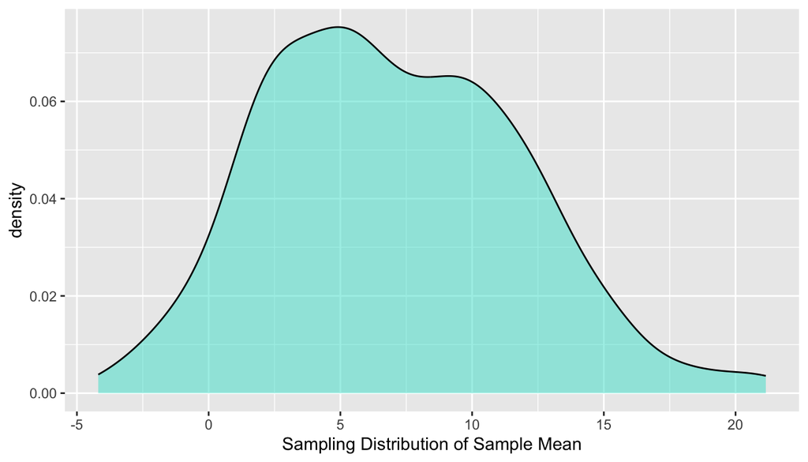

```r
ggplot(chi_25_means, aes(x=mean_arr_delay)) +
  geom_density(fill='turquoise', alpha=0.5) +
  labs(x='Sampling Distribution of Sample Mean')
```

### Discuss Reliability: Standard Error

**Standard error**: the standard deviation of the sampling distribution. It describes the width of the sampling distribution.

$$SE = \frac{s}{\sqrt{n}}$$

Example: What’s the standard error of the sample mean?

```r
favstats(~arr_delay, data=Sample100)
```

```
##  min  Q1 median    Q3 max mean       sd   n missing
##  -39 -18   -6.5 17.25 280 8.96 46.46665 100       0
```

```r
favstats(~mean_arr_delay, data=chi_25_means)
```

```
##    min     Q1 median      Q3   max   mean       sd   n missing
##  -4.19 3.2275   6.64 10.3025 21.15 7.0059 4.808579 500       0
```

A larger sample size produces a standard error that is smaller. That is, a larger sample size is more reliable than a smaller sample size.

### Discuss Readability: Approximate 95% confidence interval

**Approximate 95% Confidence interval**: If generate repeated samples, 95% of those intervals will contain the true population value.

- The interval can be used to identify plausible values for the true mean of a variable. It is calculated from the mean and standard error of the sampling distribution.

**Example**: Calculate and interpret an approximate 95% confidence interval for the mean arrival delay.

```r
chi_25_means %>%
  summarize(
    x_bar = mean(mean_arr_delay),
    se = sd(mean_arr_delay)
  ) %>%
  mutate(
    ci_lower = x_bar - 2 * se, # approximately 95% of observations
    ci_upper = x_bar + 2 * se  # are within two standard errors
  )
```

```
## # A tibble: 1 × 4
##   x_bar    se ci_lower ci_upper
##   <dbl> <dbl>    <dbl>    <dbl>
## 1  7.01  4.81    -2.61     16.6
```

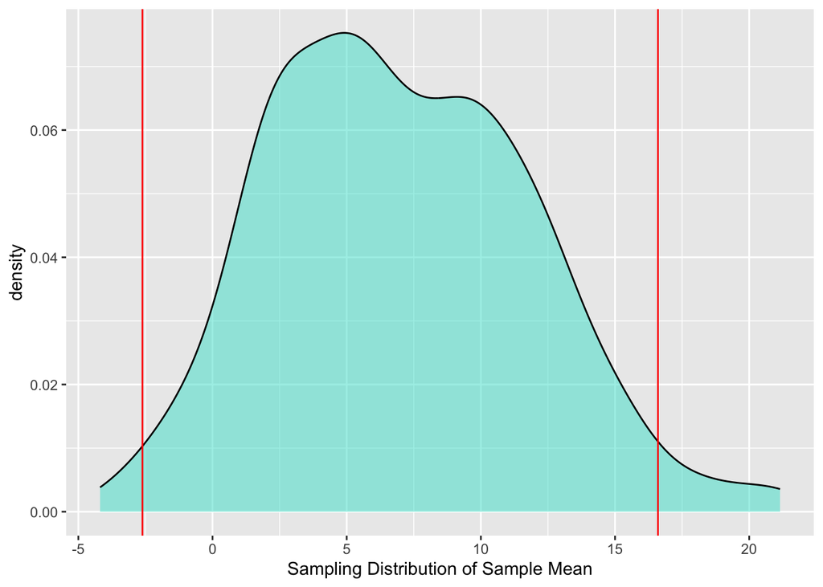

```r
ggplot(chi_25_means, aes(x=mean_arr_delay)) +
  geom_density(fill='turquoise', alpha=0.5) +
  labs(x='Sampling Distribution of Sample Mean') +
  geom_vline(xintercept=c(-2.61, 16.6), color="red") #<<
```

### How does sample size affect the sampling distribution?

```r
Means50 <- do(1000)*(Chicago %>% sample_n(size=50) %>%
                       summarize(mean=mean(arr_delay)))
Means100 <- do(1000)*(Chicago %>% sample_n(size=100) %>%
                        summarize(mean=mean(arr_delay)))
Means500 <- do(1000)*(Chicago %>% sample_n(size=500) %>%
                        summarize(mean=mean(arr_delay)))
```

```r
Means <- rbind(Means50 %>% mutate(n=50),
               Means100 %>% mutate(n=100),
               Means500 %>% mutate(n=500))
```

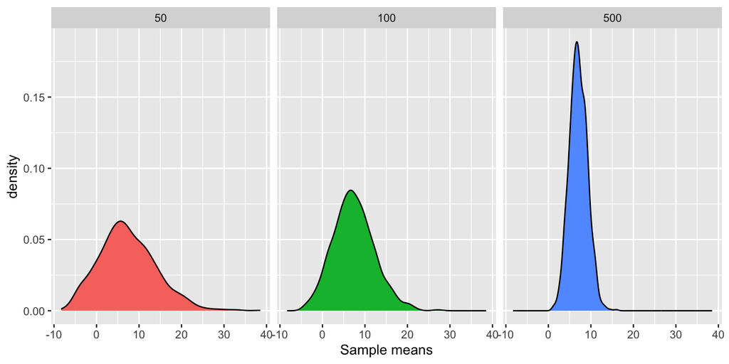

```r
ggplot(dat=Means, aes(x=mean)) +
  geom_density(aes(fill=as.factor(n))) +
  facet_grid(~n)+xlab('Sample means') + guides(fill=FALSE)
```

A larger sample size produces a smaller standard error. - A larger sample size is more reliable than a smaller sample size

What happens to the confidence interval as the standard error decreases?

- Smaller Interval

For large sample sizes, the shape of the sampling distribution tends to bell-shaped

## Bootstraping

In the last example, we had access to the population data and so we could find the sampling distribution by repeatedly sampling from the population. - We typically only have one sample and not the entire population.

**Bootstrap** is a method that allows us to approximate the sampling distribution even though we do not have the population.

In bootstraping we think of our sample as if it were the population. - So, like before, we draw many new samples from our original sample. - *Resampling*: drawing a new sample from an existing sample.

When resampling, we sample with replacement. - Allows us to estimate the variability of the sample - If we did not sample with replacement, we would always get the same sample median as the observed value.

Bootstrapping does not create new cases - It isn’t a way to collect data.

### Bootstraping: Let’s take a small sample (n=3)

```r
f3 <- Chicago %>% sample_n(size=3) %>% dplyr::select(year,month,day)
```

```r
f3
```

```
## # A tibble: 3 × 3
##    year month   day
##   <int> <int> <int>
## 1  2013    10    14
## 2  2013    12    31
## 3  2013     1     2
```

First Resample:

```r
f3 %>% slice_sample(n= 3,
               replace = TRUE)
```

```
## # A tibble: 3 × 3
##    year month   day
##   <int> <int> <int>
## 1  2013    12    31
## 2  2013    12    31
## 3  2013    10    14
```

Second Resample:

```r
f3 %>% slice_sample(n= 3,
               replace = TRUE)
```

```
## # A tibble: 3 × 3
##    year month   day
##   <int> <int> <int>
## 1  2013     1     2
## 2  2013    12    31
## 3  2013    12    31
```

### Bootstrapping: Bigger Sample

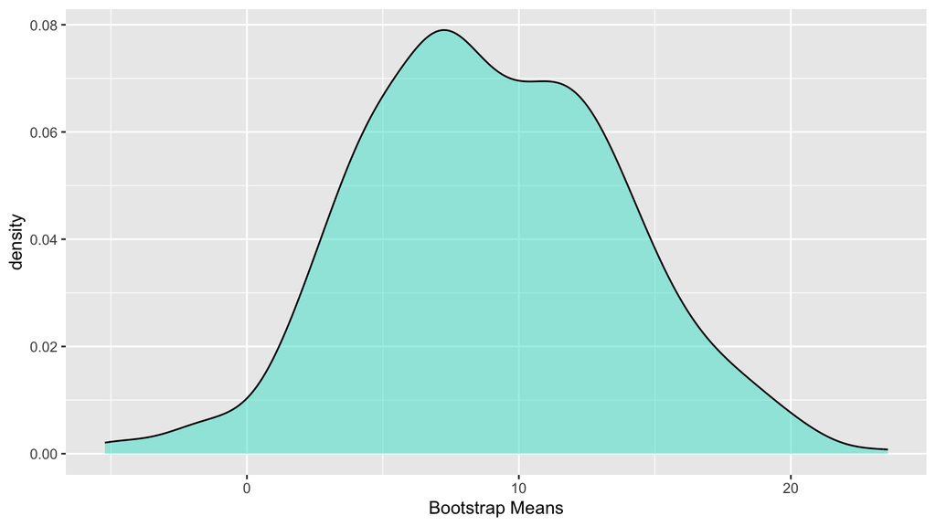

```r
Bootstrap_Means <- Sample100 %>%
  specify(response = arr_delay) %>%
  generate(reps = 500, type = "bootstrap") %>%
  calculate(stat = "mean")

ggplot(Bootstrap_Means, aes(x=stat))+
  geom_density(fill='turquoise', alpha=0.5)+labs(x='Bootstrap Means')
```

Bootstrap Sample:

```r
favstats(~stat, data=Bootstrap_Means)
```

```
##    min   Q1 median     Q3   max    mean       sd   n missing
##  -5.22 5.55  8.725 12.295 23.57 8.95738 4.739031 500       0
```

Sampling Distribution:

```r
favstats(~mean_arr_delay, data=chi_25_means)
```

```
##    min     Q1 median      Q3   max   mean       sd   n missing
##  -4.19 3.2275   6.64 10.3025 21.15 7.0059 4.808579 500       0
```

For moderate to large sample sizes and sufficient number of bootstraps, the bootstrap distribution approximates certain aspects of the sampling distribution, like the standard error and quantiles

### Example: What if we start with a different sample?

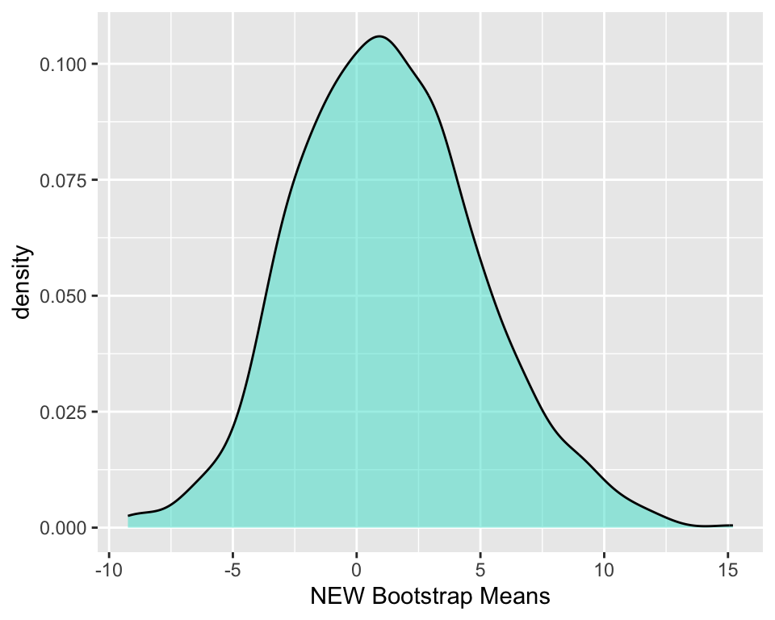

```r
NewSample <- Chicago %>% sample_n(size=100)

New_Bootstrap_Means <- NewSample %>%
  specify(response = arr_delay) %>%
  generate(reps = 1000, type = "bootstrap") %>%
  calculate(stat = "mean")

ggplot(New_Bootstrap_Means, aes(x=stat))+
  geom_density(fill='turquoise', alpha=0.5)+
  labs(x='NEW Bootstrap Means')
```

### Comparison of 3 Bootstrap Distributions

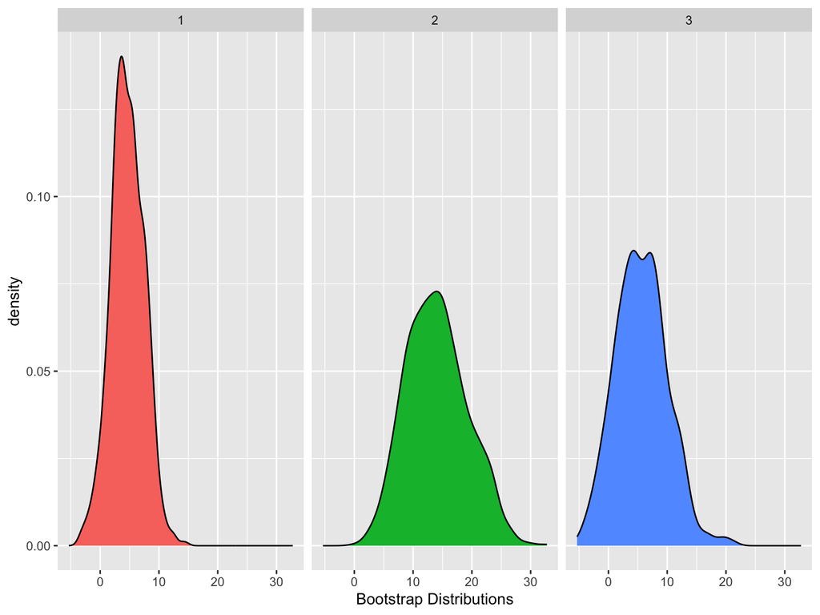

```r
Boot1 <- Chicago %>%
  sample_n(size=100) %>%
  specify(response = arr_delay) %>%
  generate(reps = 1000, type = "bootstrap") %>%
  calculate(stat = "mean")

Boot2 <- Chicago %>%
  sample_n(size=100) %>%
  specify(response = arr_delay) %>%
  generate(reps = 1000, type = "bootstrap") %>%
  calculate(stat = "mean")

Boot3 <- Chicago %>%
  sample_n(size=100) %>%
  specify(response = arr_delay) %>%
  generate(reps = 1000, type = "bootstrap") %>%
  calculate(stat = "mean")

BootSamples <- rbind(Boot1 %>% mutate(Sample=1),
               Boot2 %>% mutate(Sample=2),
               Boot3 %>% mutate(Sample=3))
ggplot(data=BootSamples, aes(x=stat)) +
  geom_density(aes(fill=as.factor(Sample))) +
  facet_grid(~Sample)+xlab('Bootstrap Distributions') +
  guides(fill=FALSE)
```

### Side Note: We want Quality Samples!

The quality of bootstrap estimates depends on the quality of the collected data. - So we want quality samples!

Quality samples tend to be representative of the population of interest

Is this class a quality sample of all Creighton students?

### Outliers

Outliers: a data point that differs significantly from other observations

When you have an outlier:

- Identify the potential outlier
- Try to understand why it is an outlier
- Only remove it if you are sure it is caused by completely random error, or not related to your research focus.

### Example: Are there any outliers in the arrival delay?

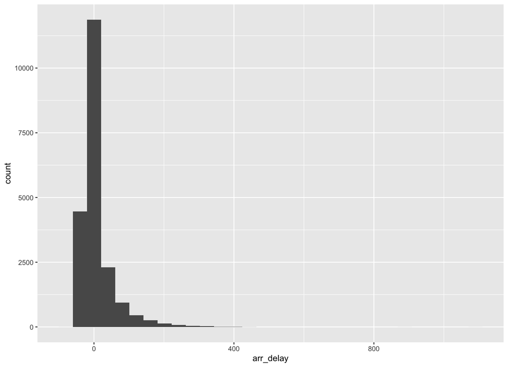

```r
ggplot(Chicago, aes(x=arr_delay)) + geom_histogram()
```

Let’s Zoom In

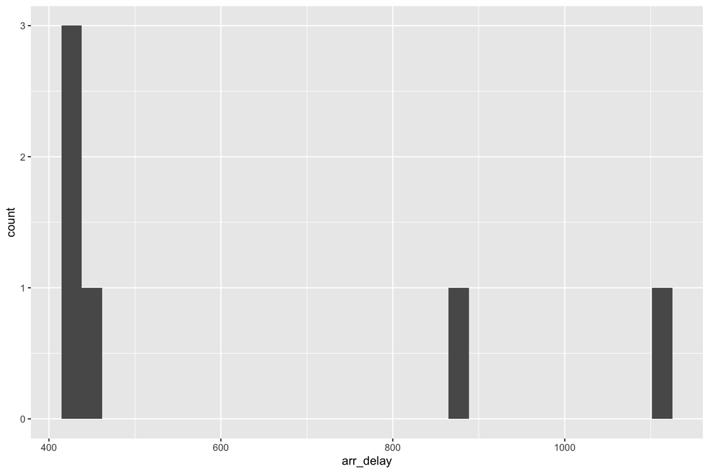

```r
Chicago %>% filter(arr_delay>400) %>% ggplot(aes(x=arr_delay)) +
  geom_histogram()
```

Any commonalities?

Do the long arrival delays have anything in common?

```r
Chicago %>% filter(arr_delay>400) %>%
  dplyr::select(month, day, dep_delay, arr_delay, carrier)
```

```
## # A tibble: 6 × 5
##   month   day dep_delay arr_delay carrier
##   <int> <int>     <dbl>     <dbl> <chr>
## 1     1    10      1126      1109 MQ
## 2     4    12       414       428 MQ
## 3     4    24       423       422 WN
## 4     5     3       878       875 MQ
## 5     5    23       466       448 AA
## 6     6    25       420       424 UA
```

## Your Turn!

1. Are long delays (over 2 hours) more common in particular months?
2. Are long delays (over 2 hours) more common with certain carriers?